# Regression Models Course Project

# Executive Summary

Here we used the `mtcars` dataset which contains the set of variables with related to miles per gallon (MPG). In this report we examined data from 32 cars to ascertain if an automatic or manual transmission is better with regards to fuel consumption.

- “Is automatic or manual transmission better for MPG”
- “Quantify this difference”

# Data Analysis

I analysis the dataset in dffrent statistical method.

## Load and Test Data

```r
library(datasets)
data(mtcars)
mpgData <- with(mtcars, data.frame(mpg, am))
mpgData$am <- factor(mpgData$am, labels = c("Automatic", "Manual"))
manual    <- as.list(subset(mtcars, am == 1, select = mpg))[[1]]
automatic <- as.list(subset(mtcars, am == 0, select = mpg))[[1]]
```

# Data Analysis

## Basic Analysis

```r
summary(mpgData[mpgData$am == "Automatic",])
```

```
##       mpg               am
##  Min.   :10.4   Automatic:19
##  1st Qu.:14.9   Manual   : 0
##  Median :17.3
##  Mean   :17.1
##  3rd Qu.:19.2
##  Max.   :24.4
```

```r
summary(mpgData[mpgData$am == "Manual",])
```

```
##       mpg               am
##  Min.   :15.0   Automatic: 0
##  1st Qu.:21.0   Manual   :13
##  Median :22.8
##  Mean   :24.4
##  3rd Qu.:30.4
##  Max.   :33.9
```

The initial comparison is simply the summary statistics between automatic and manual. The “Manual” transmission cars on average get 7.3(24.4-17.1) MORE miles to the gallon than automatic cars do.

## Basic Linear Model

```r
fit <- lm(mtcars$mpg ~ as.integer(am), data=mpgData)
summary(fit)
```

```
##
## Call:
## lm(formula = mtcars$mpg ~ as.integer(am), data = mpgData)
##
## Residuals:
##    Min     1Q Median     3Q    Max
## -9.392 -3.092 -0.297  3.244  9.508
##
## Coefficients:
##                Estimate Std. Error t value Pr(>|t|)
## (Intercept)        9.90       2.63    3.77  0.00072 ***
## as.integer(am)     7.24       1.76    4.11  0.00029 ***
## ---
## Signif. codes:  0 '***' 0.001 '**' 0.01 '*' 0.05 '.' 0.1 ' ' 1
##
## Residual standard error: 4.9 on 30 degrees of freedom
## Multiple R-squared:  0.36,   Adjusted R-squared:  0.338
## F-statistic: 16.9 on 1 and 30 DF,  p-value: 0.000285
```

### Sample Distribution: T Test

```r
data(mtcars)
t.test(manual, automatic)
```

```
##
##  Welch Two Sample t-test
##
## data:  manual and automatic
## t = 3.767, df = 18.33, p-value = 0.001374
## alternative hypothesis: true difference in means is not equal to 0
## 95 percent confidence interval:
##   3.21 11.28
## sample estimates:
## mean of x mean of y
##     24.39     17.15
```

## Improved Linear Model

Now i try to improve the linear model by using `ANOVA` The Analysis Of Variance, popularly known as the ANOVA, can be used in cases where there are more than two groups.

```r
fit2 <- update(fit, mtcars$mpg ~mtcars$am + mtcars$wt)
fit3 <- update(fit, mtcars$mpg ~mtcars$am + mtcars$wt + mtcars$qsec)
fit4 <- update(fit, mtcars$mpg ~ mtcars$am + mtcars$wt + mtcars$qsec + mtcars$cyl)
anova(fit, fit2, fit3, fit4)
```

```
## Analysis of Variance Table
##
## Model 1: mtcars$mpg ~ as.integer(am)
## Model 2: mtcars$mpg ~ mtcars$am + mtcars$wt
## Model 3: mtcars$mpg ~ mtcars$am + mtcars$wt + mtcars$qsec
## Model 4: mtcars$mpg ~ mtcars$am + mtcars$wt + mtcars$qsec + mtcars$cyl
##   Res.Df RSS Df Sum of Sq     F  Pr(>F)
## 1     30 721
## 2     29 278  1       443 71.22 4.7e-09 ***
## 3     28 169  1       109 17.55 0.00027 ***
## 4     27 168  1         2  0.24 0.62706
## ---
## Signif. codes:  0 '***' 0.001 '**' 0.01 '*' 0.05 '.' 0.1 ' ' 1
```

It is clear that the fit3 model, mpg being predicted by am, wt, and qsec gives us the strongest evidence to reject the null hypothesis.

```r
summary(fit3)
```

```
##
## Call:
## lm(formula = mtcars$mpg ~ mtcars$am + mtcars$wt + mtcars$qsec,
##     data = mpgData)
##
## Residuals:
##    Min     1Q Median     3Q    Max
## -3.481 -1.556 -0.726  1.411  4.661
##
## Coefficients:
##             Estimate Std. Error t value Pr(>|t|)
## (Intercept)    9.618      6.960    1.38  0.17792
## mtcars$am      2.936      1.411    2.08  0.04672 *
## mtcars$wt     -3.917      0.711   -5.51    7e-06 ***
## mtcars$qsec    1.226      0.289    4.25  0.00022 ***
## ---
## Signif. codes:  0 '***' 0.001 '**' 0.01 '*' 0.05 '.' 0.1 ' ' 1
##
## Residual standard error: 2.46 on 28 degrees of freedom
## Multiple R-squared:  0.85,   Adjusted R-squared:  0.834
## F-statistic: 52.7 on 3 and 28 DF,  p-value: 1.21e-11
```

```r
bestfit <- update(fit, mtcars$mpg ~ mtcars$am + mtcars$wt + mtcars$qsec + mtcars$am*mtcars$wt)
anova(fit3, bestfit)
```

```
## Analysis of Variance Table
##
## Model 1: mtcars$mpg ~ mtcars$am + mtcars$wt + mtcars$qsec
## Model 2: mtcars$mpg ~ mtcars$am + mtcars$wt + mtcars$qsec + mtcars$am:mtcars$wt
##   Res.Df RSS Df Sum of Sq  F Pr(>F)
## 1     28 169
## 2     27 117  1        52 12 0.0018 **
## ---
## Signif. codes:  0 '***' 0.001 '**' 0.01 '*' 0.05 '.' 0.1 ' ' 1
```

After trial and error (not detailed here for sake of space) I have discovered that the interaction am*wt should be included to create my bestfit model.

```r
summary(bestfit)
```

```
##
## Call:
## lm(formula = mtcars$mpg ~ mtcars$am + mtcars$wt + mtcars$qsec +
##     mtcars$am:mtcars$wt, data = mpgData)
##
## Residuals:
##    Min     1Q Median     3Q    Max
## -3.508 -1.380 -0.559  1.063  4.368
##
## Coefficients:
##                     Estimate Std. Error t value Pr(>|t|)
## (Intercept)            9.723      5.899    1.65  0.11089
## mtcars$am             14.079      3.435    4.10  0.00034 ***
## mtcars$wt             -2.937      0.666   -4.41  0.00015 ***
## mtcars$qsec            1.017      0.252    4.04  0.00040 ***
## mtcars$am:mtcars$wt   -4.141      1.197   -3.46  0.00181 **
## ---
## Signif. codes:  0 '***' 0.001 '**' 0.01 '*' 0.05 '.' 0.1 ' ' 1
##
## Residual standard error: 2.08 on 27 degrees of freedom
## Multiple R-squared:  0.896,  Adjusted R-squared:  0.88
## F-statistic: 58.1 on 4 and 27 DF,  p-value: 7.17e-13
```

Now we can see we have an adjusted R squared of 0.8804 and small p-values for the coefficients, so this model explains 88.04% of the variance in our data providing a good fit with statistically significant coefficients.

### Model Selection

A subset of parameters most relevant to mpg must be determined. To better achieve a balance between a best fit and a small variance inflation a stepwise model selection is used. Since our primary interest is in the influence of type of transmission, this variable and all its interactions are included in the model selection.

```r
var <- colnames(mtcars)[!(colnames(mtcars) %in% c("mpg", "am"))]
formula.full <- formula(paste("mpg ~ factor(am):(", paste(var, collapse = "*"),
    ")"))

null = lm(mpg ~ 1, data = mtcars)
full = lm(formula.full, data = mtcars)

model <- step(null, scope = list(lower = null, upper = full), direction = "both",
    trace = FALSE)
model$call
```

```
## lm(formula = mpg ~ factor(am):wt + factor(am):qsec, data = mtcars)
```

Note that the weight of the car and the quarter-mile-time (`qsec`) signficantly impact the `mpg` for each type of transmission.

### Model Validation

A residual analysis was done to validate the regression model. To qualify as a good model, the residuals must be, (1) Normal with 0 mean and constant variance (2) Independent, no autocorrelation (iid). Section #2 in the appendix shows a plot summary of the residuals of the model. The “Residuals vs Fitted” and “Scale-Location” charts show that there is no trend to the residuals. The Q-Q plot shows that the the errors are approximately normally distributed.

### Model Interpretation

```r
summary(model)
```

```
##
## Call:
## lm(formula = mpg ~ factor(am):wt + factor(am):qsec, data = mtcars)
##
## Residuals:
##    Min     1Q Median     3Q    Max
## -3.936 -1.402 -0.155  1.269  3.886
##
## Coefficients:
##                  Estimate Std. Error t value Pr(>|t|)
## (Intercept)        13.969      5.776    2.42   0.0226 *
## factor(am)0:wt     -3.176      0.636   -4.99  3.1e-05 ***
## factor(am)1:wt     -6.099      0.969   -6.30  9.7e-07 ***
## factor(am)0:qsec    0.834      0.260    3.20   0.0035 **
## factor(am)1:qsec    1.446      0.269    5.37  1.1e-05 ***
## ---
## Signif. codes:  0 '***' 0.001 '**' 0.01 '*' 0.05 '.' 0.1 ' ' 1
##
## Residual standard error: 2.1 on 27 degrees of freedom
## Multiple R-squared:  0.895,  Adjusted R-squared:  0.879
## F-statistic: 57.3 on 4 and 27 DF,  p-value: 8.42e-13
```

See Section #3 in the appendix for a co-plot of parameters in the model by transmission type.

#### For constant quarter-mile-time (qsec):

For each unit of increase in weight (1 unit = 1000lb) there is a 3.176 mpg **decrease** for automatic cars while there is a 6.099 mpg **decrease** for manual cars. This makes physical sense as heavier cars in general would require more fuel.

#### For constant weight (lb/1000):

For each unit of increase in quarter-mile-time (1 unit = 1 sec), there is a 0.834 mpg increase for automatic cars while there is 1.446 mpg increase for manual cars.

# Results

So from the `Linear model` and `Basic analysis` gave us manual transmission is better than automatic for MPG, which increased by 7.2449,and from `Improved Linear Model` difference between an automatic and manual car, a manual transmission car gets 14.079 more miles to the gallon than an Automatic - 4.141 * the weight.

- Now answer to Q1 can say manual transmission is better than automatic
- Now answer to Q2 manual transmission is better than automatic for MPG, which increased by 7.2449.

## APPENDIX: PLOTS

### 1. Boxplot (`am`) vs `mpg`

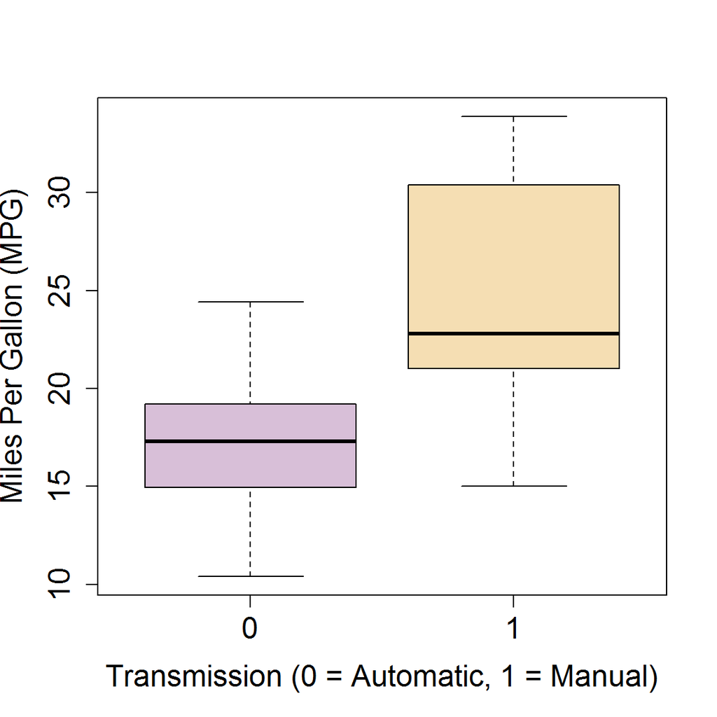

### 2. Residuals: `model`

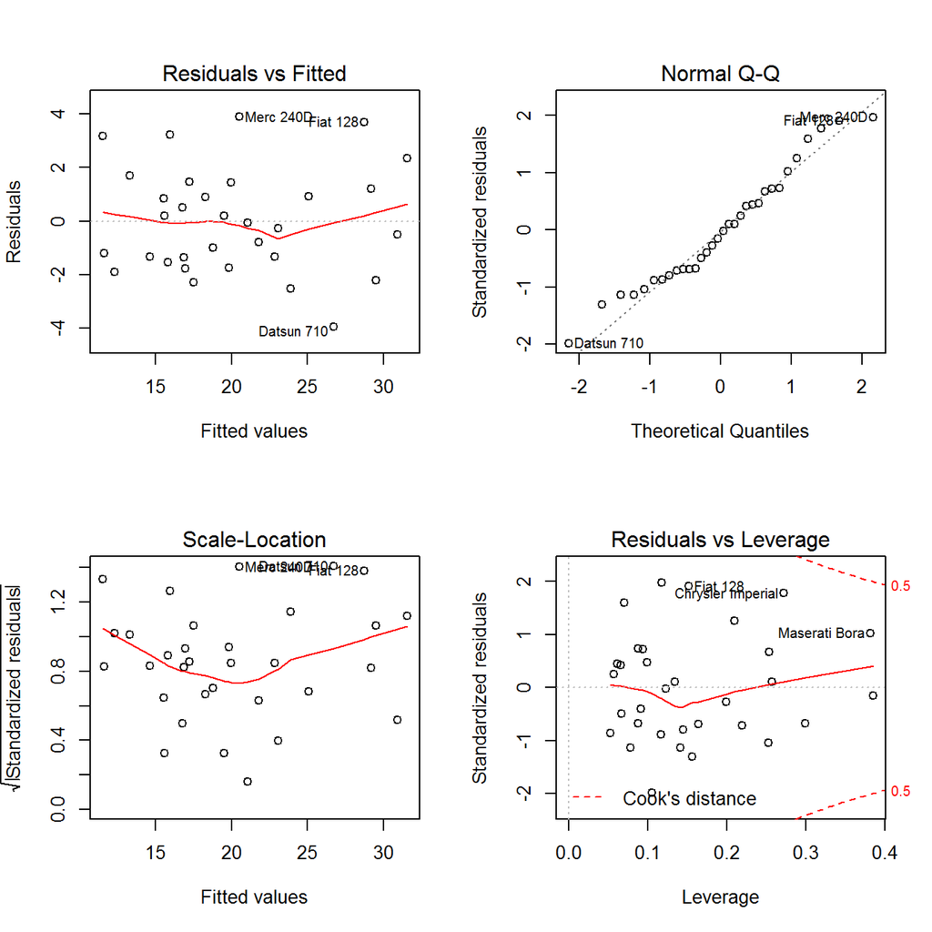

### 3. CoPlot: Fit by transmission type (`am`)

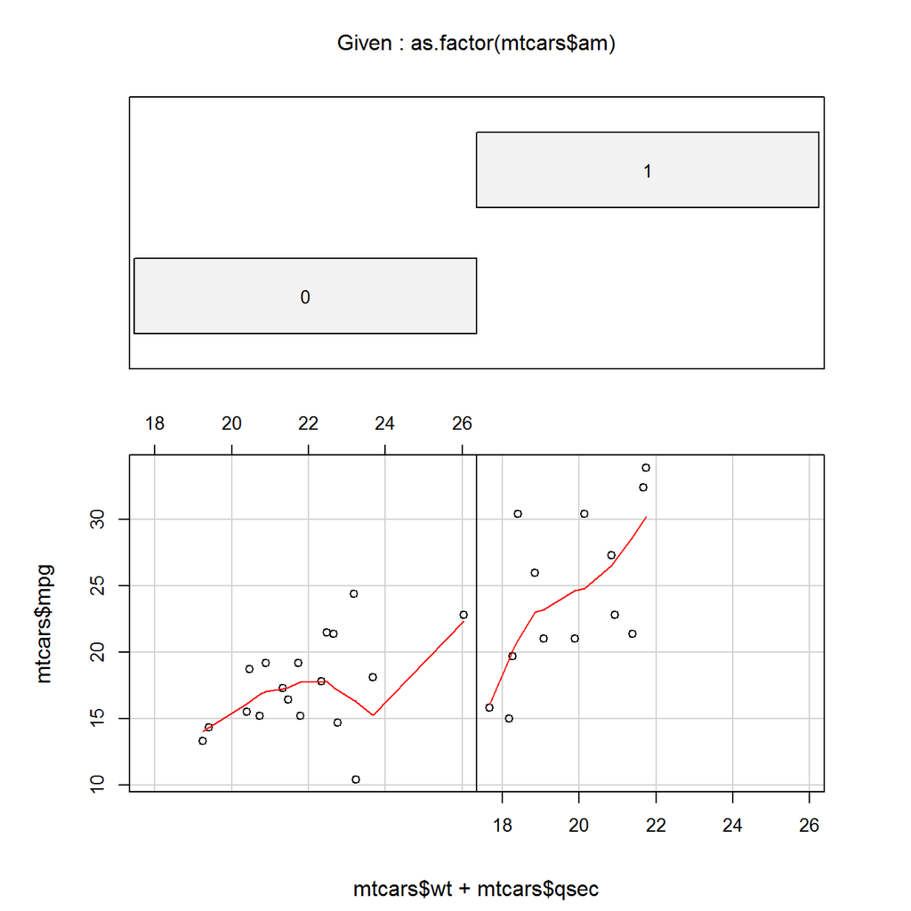